# Gov 50 Final Project

Bryn Evans

Description: I want to take government data on interest rates since the inception of the Federal Reserve, and compare that using linear regression to overall GDP by year for the United States, to see the relationship of interest rates with GDP.

## Project thoughts

I am interested in exploring government data on yearly Federal Funds interest rates since the inception of the Federal Reserve, and compare that using linear regression to overall U.S. GDP by year, to see the relationship of interest rates with GDP.

Research proposal: Do Federal Funds Rates set by the Federal Reserve affect the Gross Domestic Product, or economic productivity of the United States? In this study, I intend to examine the relationship with the Federal Funds Rate and US GDP. The Federal Funds Rate is an interest rate set by the Federal Reserve that determines how expensive it is for banks to lend to each other overnight. Overnight lending is typically used to satisfy capital reserves requirements for banks. The broadly accepted perspective is that the set Federal Funds Rate affects the entire economy, because a higher rate causes lending to be more expensive, triggering a slow-down in the economy. Conversely, if the Federal Funds Rate is lower, then it is less expensive to lend, which typically stimulates growth throughout the economy. Gross Domestic Product, or GDP, is the amount of goods that are created and sold on a yearly basis within the United States. My hypothesis is the Federal Funds Rate has a negative relationship with U.S. GDP numbers, meaning that when the Federal Funds Rate is higher, the U.S. GDP will be lower.

I will use a regression analysis to examine the relationship of these two variables. The Federal Funds Rate is a number that typically ranges from 0%-5%, but can fluctuate to 20% or below 0% in extreme cases. The GDP is measured as followed: private consumption + gross private investment + government investment + government spending + (exports – imports). GDP is usually calculated by the national statistical agency of the country following the international standard. The yearly GDP number is a dollar amount. For example, the 2021 U.S. GDP for 2021 was $23 trillion.

A negative relationship between the two variables would provide support for my hypothesis, and a positive relationship between the two variables would disprove my hypothesis.

Data on Federal Funds Interest Rates by year since 1954 (the first year they were documented): https://fred.stlouisfed.org/series/FEDFUNDS Data on U.S. GDP by year since 1947 (the first year they were documented): https://fred.stlouisfed.org/series/GDP

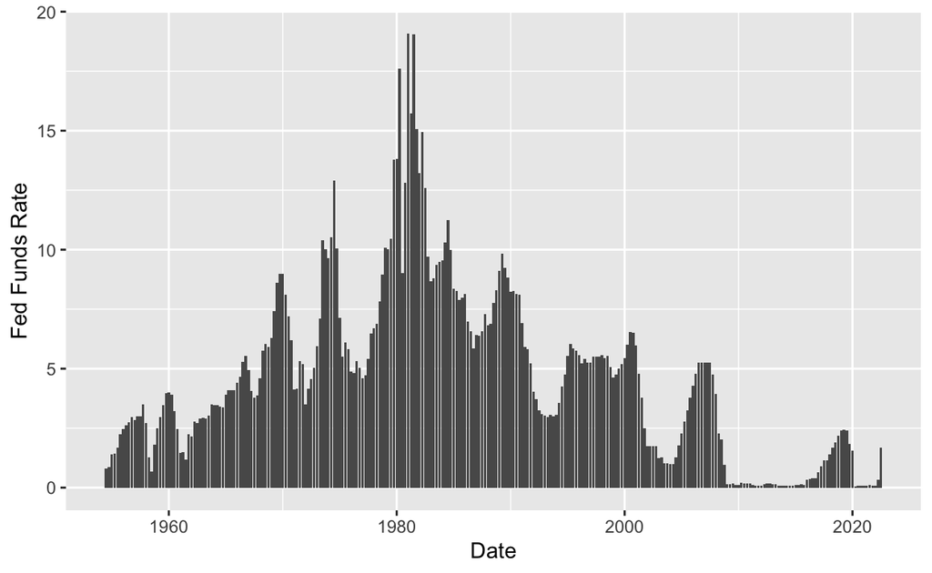

```r
library(tidyverse)
library(dplyr)
library(ggplot2)
library(modelsummary)

GDP <- read_csv("GDP.csv")
FedFundsRate <- read_csv("FedFundsRate.csv")

GDP_And_Fed_Funds_Rates <-  merge(GDP, FedFundsRate, by="DATE")
names(GDP_And_Fed_Funds_Rates)[3] = "Fed Funds Rate"
names(GDP_And_Fed_Funds_Rates)[1] = "Date"

GDP_And_Fed_Funds_Rates <- GDP_And_Fed_Funds_Rates |>
  arrange(Date) |> # first sort by Date
  mutate(GDP_change_percent = ((GDP - lag(GDP)) / GDP) * 100, # Difference in GDP between Dates
         Rate_percent = (GDP_change_percent /lag(GDP) * 100),
         Date_lag =  lag(Date, 10))# growth rate in percent

regression <- lm(GDP ~ `Fed Funds Rate` + Date_lag, GDP_And_Fed_Funds_Rates)

ggplot_fed_funds_rates <- ggplot(data = GDP_And_Fed_Funds_Rates, mapping = aes(x = Date, y = `Fed Funds Rate`)) +
  geom_col()

ggplot_GDP <- ggplot(data = GDP_And_Fed_Funds_Rates, mapping = aes(x = Date_lag, y = GDP)) +
  geom_col() +
   labs(x = " Date (Lagged by 1-2 years)")

ggplot_GDP_growth_rate <- ggplot(data = GDP_And_Fed_Funds_Rates, mapping = aes(x = Date_lag, y = GDP_change_percent)) +
  geom_col() +
  labs(x = " Date (Lagged by 1-2 years)", y = "GDP Change (%)")

ggplot_regression <- ggplot(data = GDP_And_Fed_Funds_Rates, mapping = aes(x =`Fed Funds Rate`, y = GDP)) +
  geom_point() +
  geom_smooth(method = "lm")

ggplot_fed_funds_rates
```

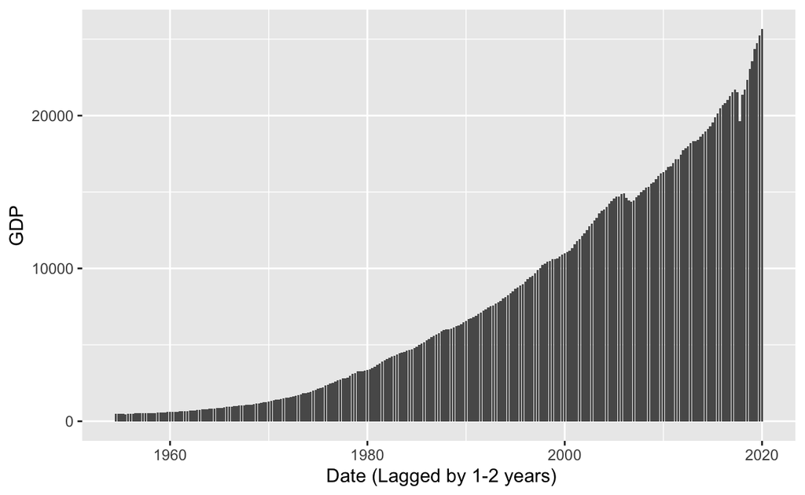

```r
ggplot_GDP
```

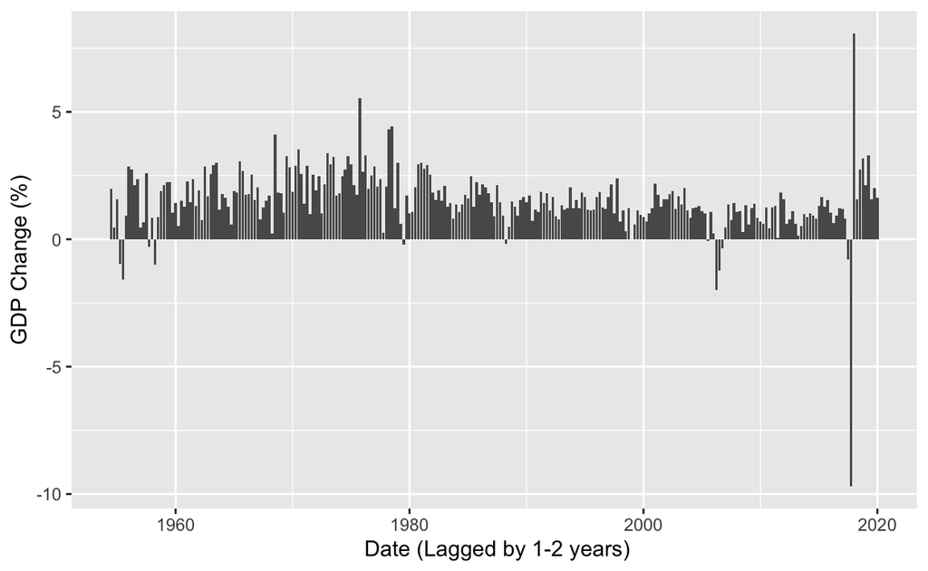

```r
ggplot_GDP_growth_rate
```

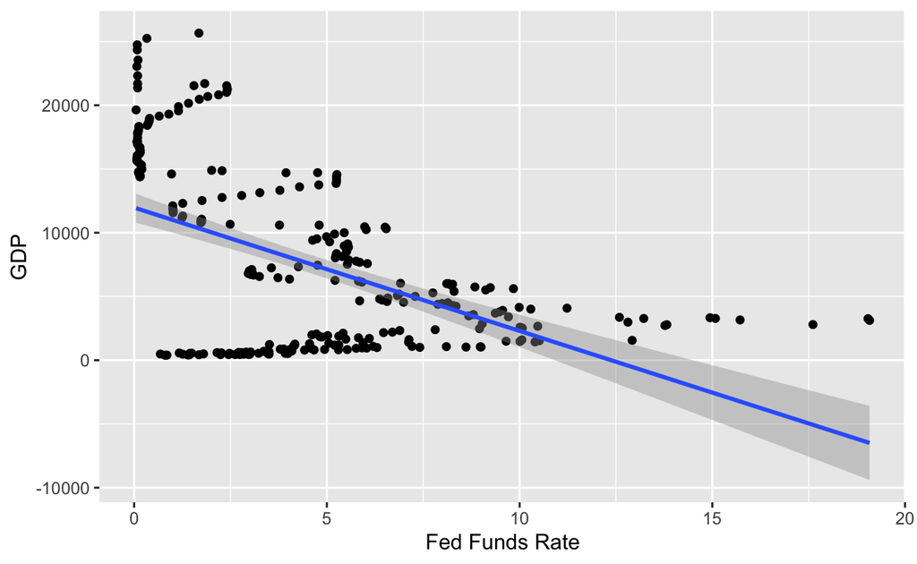

```r
ggplot_regression
```

```r
modelsummary(regression,
             estimate = c("{estimate}{stars}"),
             gof_omit = c("IC|Lik.|RMSE"))
```

|  | Model 1 |
| --- | --- |
| (Intercept) | 3926.835*** |
|  | (219.225) |
| Fed Funds Rate | −356.667*** |
|  | (28.828) |
| Date_lag | 0.880*** |
|  | (0.015) |
| Num.Obs. | 263 |
| R2 | 0.949 |
| R2 Adj. | 0.949 |

## Results From One Analysis:

I have produced 4 plots. The first shows the relationship between federal funds rates over time, the second shows the effective GDP over time (lagged for 1-2 years for accuracy), the third shows the growth rate of the GDP over time with lag accounted for, and the fourth shows the linear regression relationship between GDP and federal funds rates

## Final Report:

**Introduction:** My research question asked if there was a causal relationship between the U.S. federal funds rate, which determines the price of overnight lending by banks to other banks, and the overall U.S. gross domestic product, or GDP. This question is interesting because the federal funds rate is typically understood to affect interest rates at large throughout the U.S. economy. So, if the Federal Reserve, which sets the federal funds rate, decides a higher interest rate, this is typically believed to slow economic growth, and borrowing becomes more expensive and companies do not want to take on as much debt, which can help facilitate growth. Based on this, my hypothesis was that there was a negative relationship between the federal funds rate and overall U.S. GDP year-over-year, starting when the the data was first collected in 1954 to present day in 2022. This means that if interest rates went up, meaning that borrowing went down, GDP would go down.

The independent variable in this study is the federal funds rate, and the dependent variable is GDP by year, because I am hypothesizing that the federal funds rate has a direct effect on GDP.

**Results:** In my regression analysis, the main coefficient of interest was the coefficient between the federal funds rate and GDP, which came out to -356 when accounting for lag, meaning that when interest rates increase by a full point, GDP decreases by $356B. This coefficient shows a strong negative relationship between the federal funds rates and GDP.

I also ran the regression with the date in mind. The date coefficient was .88 (with lag accounted for), meaning every time date increased by 1, GDP increased by $880M. This is in line with estimates, as GDP has steadily rose throughout time.

**Summary:** My results did support my hypothesis that there is a strong negative relationship between federal funds rates and GDP. A limitation of my analysis was that data has only been tracked for 68 years, which may not be enough time to show a causal relationship. Some threats to inference or confounding variables could be other macroeconomic factors in the environment that had effects on GDP, such as geopolitical events, trade wars, shortages/ surpluses of certain goods, or boom/ bust economic cycles. My analysis could be improved by gathering other data like the above that could have a confounding effect, and test that data for a null hypothesis to ensure that it did not have a confounding effect.

The takeaway from this research project is that the Federal Reserve must be very careful, thoughtful, and sparing in their decision to change interest rates, as this has a profound effect on the U.S. and global economy. An increase in the interest rates that is not needed can adversely affect billions of lives around the world, which is why those at the Federal Reserve must be very calculated and responsbile in their actions.